# Data Analysis Project: Knee Replacement Surgery Outcomes

Analysis Project

Gitika Jain (gitikaj2)

Heather Sewak (hsewak2)

Ionel Miu (imiu2)

Jared Michael Colbert (jaredc2)

December 14, 2016

# Knee Replacement Surgery Outcome

## Introduction

This research aims to determine if the postoperative function of a total knee replacement recipient can be modeled based on anthropomorphic data, and details of the surgical procedure. We decided to carry out testing on models with two postoperative scoring systems as the response variable. The first score is the “Surgeon’s Score” which measures more objective postoperative metrics about the condition of the replaced knee following surgery. These metrics include: how straight or how flexed the patient can make their knee, how well aligned the knee appears when inspecting from a frontal perspective, and how much laxity or separation can be achieved by placing the lower leg under tension. Finally, the patient is asked about the overall pain they experience with the knee. The resulting score is a value between 0-100 with 80-100 being an excellent result.

The second score we modeled is the “Patient’s Score” which is generated by three questions: how far are they able to walk, how well can they navigate stairs, and do they require any walking aids (crutches, cane, etc).

We hope to create a model that can predict each of the scores based on a variety of categorical and numeric predictors.

## Background information

This data has been collected from a Southern California Hospital in collaboration with the Shiley Center for Orthopedic Research. The data is used for both clinical research and postoperative monitoring of implant survivorship. All patient specific information has been removed from the data so it adheres to the Health Insurance Portability and Accountability Act (HIPAA).

### Synopsis of Workflow

#### Outline Questions

After we had obtained a copy of the current patient database we spent some time inspecting each of the columns to ensure that the team had a consistent understanding of what each datapoint measures and how it is collected. We then crafted a series of questions we could ask and speculated on how each of the datapoints might be organized in various models. It was apparent to us that the response variables would have to be the Surgeon or Patient scores since each of our questions sought to explain factors that determine a patient’s satisfaction after surgery. The two scores are the only concrete datapoint with which we could measure a post-surgical outcome.

#### Data Preparation

The original dataset was full of errant or missing fields which required cleaning. Because the complete dataset is quite large, we were able to drop all rows with missing or NA values while retaining nearly two thousand entries. We then used some visualization techniques to get a ‘feel’ for which items may be appropriate to utilize in a model. Finally, the data was separated into training and testing groups.

#### Initial Model

We then began model creation starting with a full additive model. Upon evaluation we found the model to be a poor fit with metrics not satisfying any of our criteria for a reasonable model. While testing for leverages we spotted some errant entries that remained in the dataset so a second cleaning pass through the data was required.

#### Selective, AIC, BIC and Interactive Models

Next we checked for variance between the full model and all iterations of models with a single predictor removed. This process resulted in a collection of six significan predictors which were then utilized in fitting a smaller model. AIC and BIC selection was performed also performed and the assumptions were tested after each model was created. Since no antecedent model performed as hoped, we turned to a series of interactive models. We utilized the anova function extensively to determine if the variance between models was significant.

#### Removing Leverage

We then hypothesized that the outliers in the data might be hindering our ability to fit a model with a sufficiently hight Adjusted $R^2$. The values with a high Cook’s Distance were identified and removed from subsequent models.

## Statement

We hope to determine the impact a particular surgeon or the type of implants used has on the patient’s outcome after surgery. We are also interested in exploring the potential relationship between anthropomorphic factors and the patient’s postoperative satisfaction. Finally, we would like to understand if the considerable expense of computer navigation in knee replacement leads to better postoperative scores. Nevertheless, we keep our options opened to investigate other aspects that were not ‘visible’ or thought about but might reveal themselves as we move on with the project.

Here we may consider *KneeScore_Surgeon* or *KneeScore_Patient* as response and *Age, Gender, Weight, Height, BMI, Race, Side, Manufacturer* as predictors. *Gender, Race, Side and Manufacturer* are some of the categorical predictors and *Age, Height, Weight and BMI* are numerical predictors.

```r
knee = read.csv('knees.csv')
knee$Surgeon = as.factor(knee$Surgeon)
knee$Year = as.factor(knee$Year)
```

### Functions for Model Evaluation

```r
#Function to plot various plots as QQPlot, Fitted vs Residual Plot.
showPlots = function(model) {
  par(mfcol=c(1,3))
  qqnorm(resid(model), col = red, pch = 16)
  qqline(resid(model), col = lightblue, lwd = 2)
  plot(fitted(model), resid(model), xlab = 'Fitted Values', ylab = 'Residuals', main = 'Fitted vs. Residuals Plot', col = purple, pch = 16)
  abline(h = 0, col = green, lwd = 2)
  hist(resid(model), col = blue, main = 'Histogram of Residuals', xlab = 'Residuals')
}

#Function to calculate various statistics which we use to evaluate the model
evaluate = function(model){
  # Run each of the tests
  lambda = 1.000001 # this is a hack so the function will return a CrossValidation score - HatValues of 1.0 are causing a division by zero error.
  shapiroTest = shapiro.test(resid(model))
  bpTest = bptest(model)
  rSquared = summary(model)$r.squared
  adjRSquared = summary(model)$adj.r.squared
  loocv = sqrt(mean((resid(model) / (lambda - hatvalues(model))) ^ 2))
  large_hat = sum(hatvalues(model) > 2 * mean(hatvalues(model)))
  large_resid = sum(rstandard(model)[abs(rstandard(model)) > 2]) / (length(rstandard(model) + lambda))
  large_cooks = sum(cooks.distance(model) > 4 / length(cooks.distance(model)))

  # Collect tests in dataframe
  values = data.frame(Result = c(prettyNum(shapiroTest$p.value), prettyNum(bpTest$p.value), prettyNum(rSquared), prettyNum(adjRSquared),prettyNum(loocv), prettyNum(large_hat), prettyNum(large_cooks)))
  rowNames = data.frame(Test = c('Shapiro Wilk pvalue', 'Breusch-Pagan pvalue', 'R Squared', 'Adj R Squared', 'Cross Validation', 'Large Hat Values', 'Influential'))

  summary_output = cbind(rowNames, values)
  show(summary_output)
  showPlots(model)
}
# find and remove all influential values and return the resulting dataframe
removeInfluential = function(model, data){
  cooks = which(cooks.distance(model) > 4 / length(cooks.distance(model)))
  newData = data[-cooks , ]
  return(newData)
}

# identify all influential data points
IdentifyInfluential = function(model, data){
  cooks = which(cooks.distance(model) > 4 / length(cooks.distance(model)))
  return(index_)
}

# calculate RMSE
rmse  = function(actual, predicted) {  sqrt(mean((actual - predicted) ^ 2))}
```

### Knee Score Surgeon

Before moving onto the formal analysis of our data set, we started by performing visual inspection by plotting dependencies among our the variables. The main focus was to look for any visual relationship between `KneeScore_Surgeon, KneeScore_Patient` and the rest of the variables. Our choice was to use `scatterplotMatrix` from the `car` package as it plots regression lines along with the actual data.

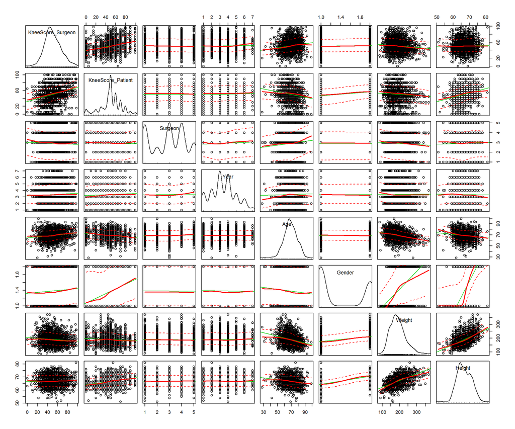

```r
scatterplotMatrix(~ KneeScore_Surgeon + KneeScore_Patient + Surgeon + Year + Age + Gender + Weight + Height, span=0.7, data=knee)
```

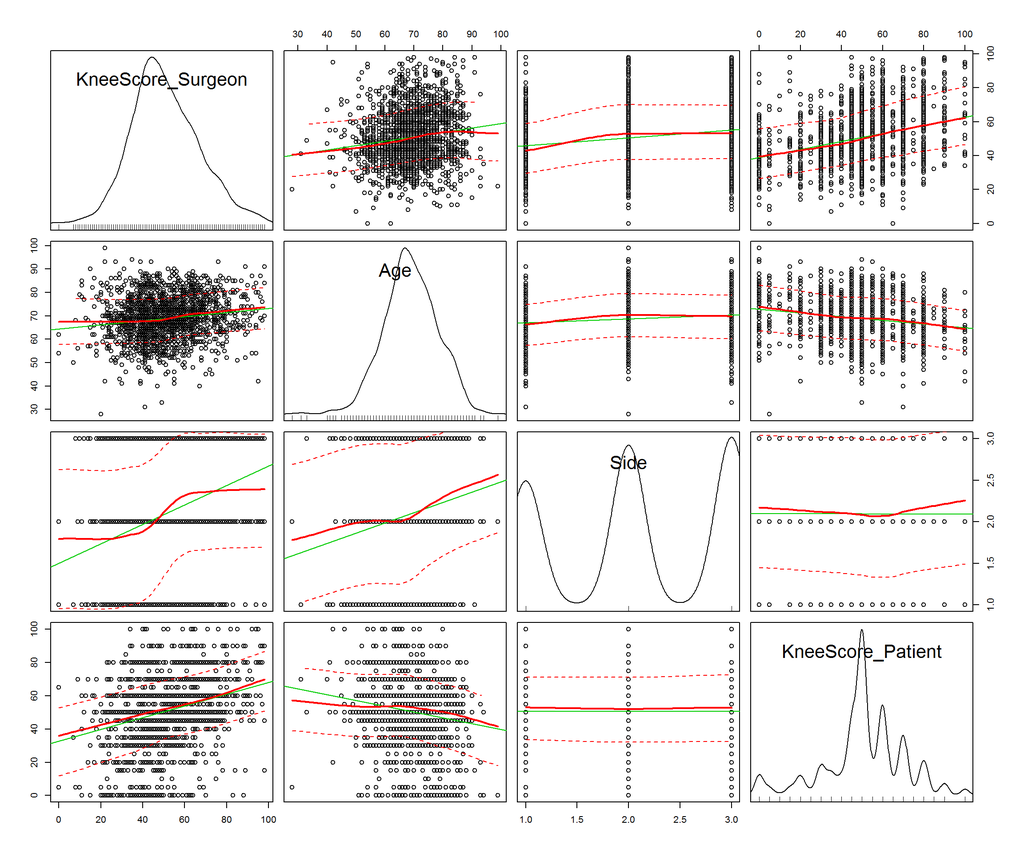

```r
scatterplotMatrix(~ KneeScore_Surgeon * Age * Side * KneeScore_Patient, span=0.7, data=knee)
```

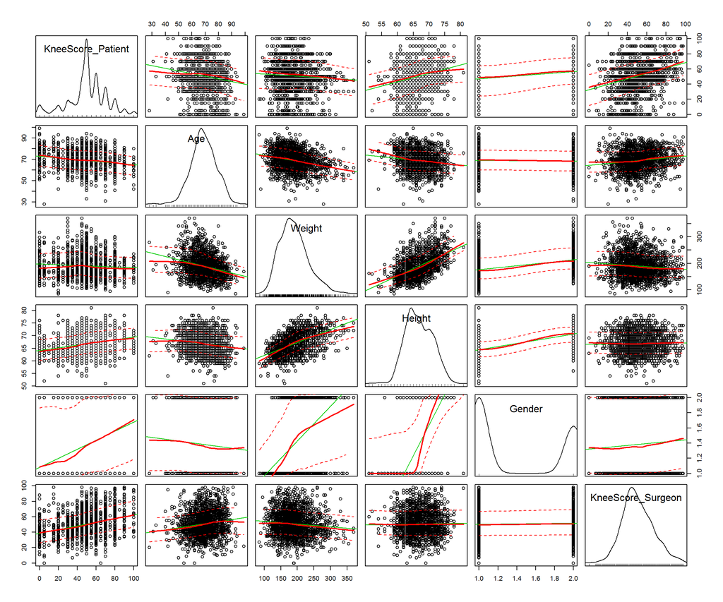

```r
scatterplotMatrix(~ KneeScore_Patient * Age * Weight * Height * Gender * KneeScore_Surgeon, span=0.7, data=knee)
```

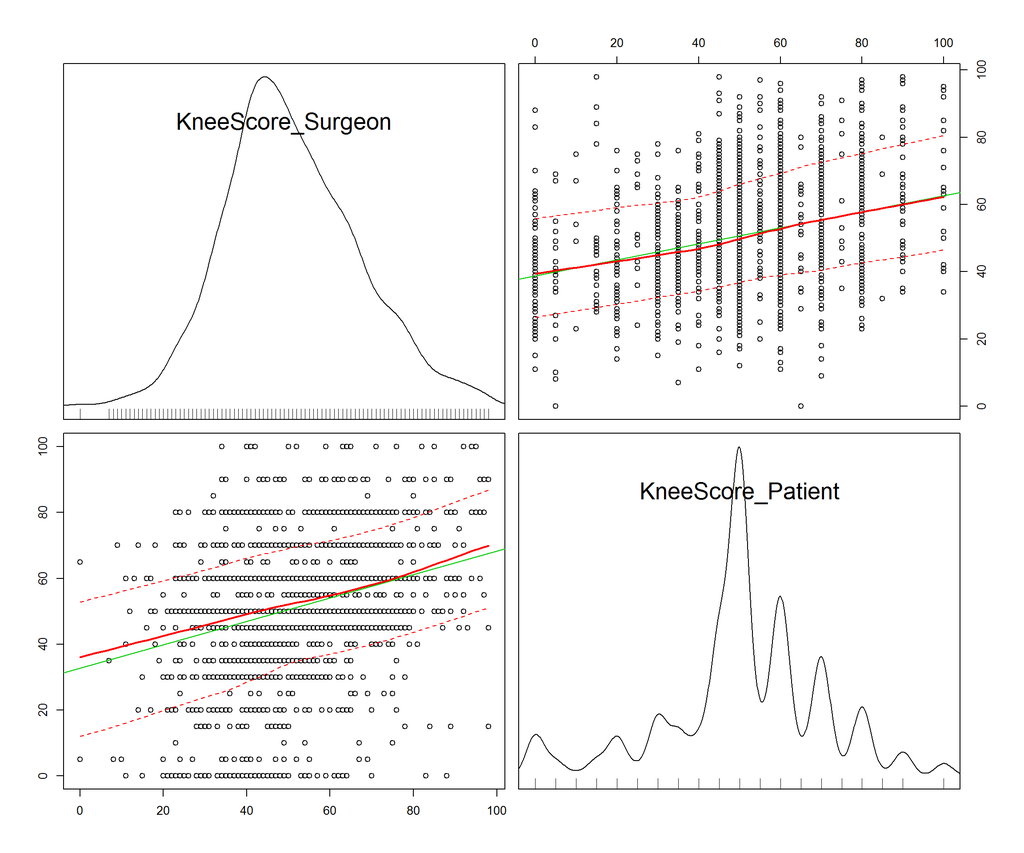

```r
scatterplotMatrix(~ KneeScore_Surgeon + KneeScore_Patient, span=0.7, data=knee)
```

The distribution of `KneeScore_Surgeon` which reflects the score of a procedure assigned be the `Surgeon` is unimodal distribution versus a multimodal distribution of `KneeScore_Patient`, which is the score assigned by `Patient`. Our explanation of this is that `Surgeon` assigns any number between 1 and 100 without any discretion whereas `Patient` has a tendency to round up the score to the nearest fifth (Ex: 5, 10, 35, 50, etc) which creates the multi-picks of the distribution.

Begin by fitting a full additive model as a baseline and evaluating.

```r
sample_idx = sample(1:nrow(knee), 1500)
train_data = knee[sample_idx, ]
test_data = knee[-sample_idx, ]

surgeon_full_additive_model = lm(KneeScore_Surgeon ~ ., data = train_data)
evaluate(surgeon_full_additive_model)
```

```
##                   Test      Result
## 1  Shapiro Wilk pvalue 9.73863e-07
## 2 Breusch-Pagan pvalue   0.2482625
## 3            R Squared   0.2650036
## 4        Adj R Squared   0.2158294
## 5     Cross Validation    14.37625
## 6     Large Hat Values         166
## 7          Influential          NA
```

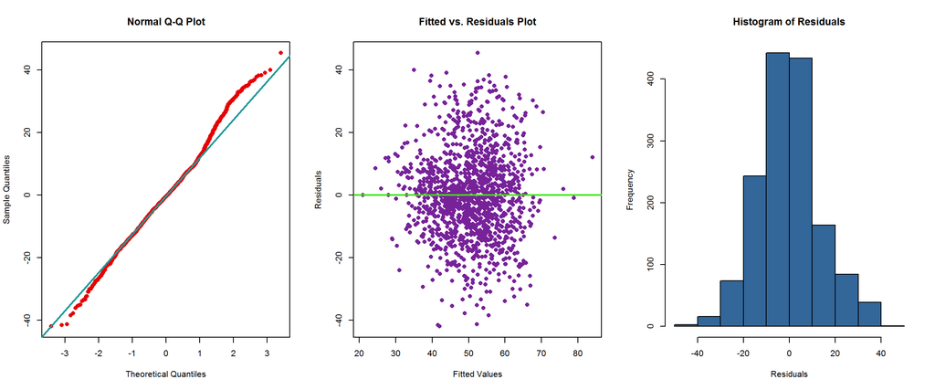

The baseline model has many large hat values. Let’s try to understand why.

```r
largeHat = which(hatvalues(surgeon_full_additive_model) > (2 * mean(hatvalues(surgeon_full_additive_model))))
print(knee[615, ])
```

```
##     Surgeon Year Age Gender Weight Height   BMI      Diagnosis  Race
## 615       3 2012  68 Female    212     63 37.59 Osteoarthritis White
##          Side KneeScore_Surgeon KneeScore_Patient GPS Manufacturer
## 615 Bilateral                31                15 Yes  DePuy (J&J)
##     FemoralComponentModel FemoralComponentSize FemoralComponentType
## 615                 Sigma                   4N   cruciate retaining
##     TibialTrayModel TibialTraySize TibialInsertModel TibialInsertWidth
## 615       PFC Sigma              3         PFC Sigma                 8
##         TibialInsertType            PatellaModel PatellaDiameter
## 615 curved,Fixed bearing Oval Dome Patella 3-peg              32
```

After inspection of the rows that represent the large hat values it seems that there are a preponderance of values that are either errant entries or valid, but rare entries. For example, the `Race` predictor has only two entries for `Mid-East Arabian`. First we circle back on the original dataset and clean the identified errant entries.

Next we will try to determine which predictors are significant by comparing the full model to models each with a single predictor removed. Evaluation of this code is set to false for convienience. Comments show the significance of each test.

```r
surgeon_additive_model = lm(KneeScore_Surgeon ~ .-Surgeon, data = train_data)
Gender_additive_model = lm(KneeScore_Surgeon ~ .-Gender, data = train_data)
Race_additive_model = lm(KneeScore_Surgeon ~ .- Race, data = train_data)
Year_additive_model = lm(KneeScore_Surgeon ~ .- Year, data = train_data)
Age_additive_model = lm(KneeScore_Surgeon ~ .- Age, data = train_data)
Weight_additive_model = lm(KneeScore_Surgeon ~ .- Weight, data = train_data)
Height_additive_model = lm(KneeScore_Surgeon ~ .- Height, data = train_data)
BMI_additive_model = lm(KneeScore_Surgeon ~ .- BMI, data = train_data)
Diagnosis_additive_model = lm(KneeScore_Surgeon ~ .- Diagnosis, data = train_data)
Side_additive_model = lm(KneeScore_Surgeon ~ .- Side, data = train_data)
KneeScore_Patient_additive_model = lm(KneeScore_Surgeon ~ .- KneeScore_Patient, data = train_data)
GPS_additive_model = lm(KneeScore_Surgeon ~ .- GPS, data = train_data)
Manufacturer_additive_model = lm(KneeScore_Surgeon ~ .- Manufacturer, data = train_data)
FemoralComponentModel_additive_model = lm(KneeScore_Surgeon ~ .- FemoralComponentModel, data = train_data)
FemoralComponentSize_additive_model = lm(KneeScore_Surgeon ~ .- FemoralComponentSize, data = train_data)
FemoralComponentType_additive_model = lm(KneeScore_Surgeon ~ .- FemoralComponentType, data = train_data)
TibialTrayModel_additive_model = lm(KneeScore_Surgeon ~ .- TibialTrayModel, data = train_data)
TibialTraySize_additive_model = lm(KneeScore_Surgeon ~ .- TibialTraySize, data = train_data)
TibialInsertModel_additive_model = lm(KneeScore_Surgeon ~ .- TibialInsertModel, data = train_data)
TibialInsertWidth_additive_model = lm(KneeScore_Surgeon ~ .- TibialInsertWidth, data = train_data)
TibialInsertType_additive_model = lm(KneeScore_Surgeon ~ .- TibialInsertType, data = train_data)
PatellaModel_additive_model = lm(KneeScore_Surgeon ~ .- PatellaModel, data = train_data)
PatellaDiameter_additive_model = lm(KneeScore_Surgeon ~ .- PatellaDiameter, data = train_data)

anova(surgeon_additive_model,surgeon_full_additive_model) ## Not significant Pr(<F) 0.2061
anova(Gender_additive_model,surgeon_full_additive_model) ## Not significant Pr(<F) 0.3678
anova(Race_additive_model,surgeon_full_additive_model) ## Not significant Pr(<F) 0.3949
anova(Year_additive_model,surgeon_full_additive_model) ## * Some significance Pr(<F) 0.039
anova(Age_additive_model,surgeon_full_additive_model) ## *** Significant Pr(<F) 1.191e-11
anova(Weight_additive_model,surgeon_full_additive_model) ## Not significant Pr(<F) 0.4295
anova(Height_additive_model,surgeon_full_additive_model) ## Not significant Pr(<F) 0.6232
anova(BMI_additive_model,surgeon_full_additive_model) ## Not significant Pr(<F) 0.4046
anova(Diagnosis_additive_model,surgeon_full_additive_model) ## Marginally Significant Pr(<F) 0.067
anova(Side_additive_model,surgeon_full_additive_model) ## *** Significant Pr(<F) 2.2e-16
anova(KneeScore_Patient_additive_model,surgeon_full_additive_model) ## *** Significant Pr(<F) 2.2e-16
anova(GPS_additive_model,surgeon_full_additive_model) ## Not significant Pr(<F) 0.4046
anova(Manufacturer_additive_model,surgeon_full_additive_model) ## Not significant Pr(<F) 0.7153
anova(FemoralComponentModel_additive_model,surgeon_full_additive_model) ## Not significant Pr(<F) 0.1388
anova(FemoralComponentSize_additive_model,surgeon_full_additive_model) ## Not significant Pr(<F) 0.3345
anova(FemoralComponentType_additive_model,surgeon_full_additive_model) ## Not significant Pr(<F) 0.5606
anova(TibialTrayModel_additive_model,surgeon_full_additive_model) ## Not significant Pr(<F) 0.8707
anova(TibialTraySize_additive_model,surgeon_full_additive_model) ## Not significant Pr(<F) 0.1527
anova(TibialInsertModel_additive_model,surgeon_full_additive_model) ## * Some significance Pr(<F) 0.043
anova(TibialInsertWidth_additive_model,surgeon_full_additive_model) ## Not significant Pr(<F) 0.721
anova(TibialInsertType_additive_model,surgeon_full_additive_model) ## Not significant Pr(<F) 0.613
```

Since there are only a few predictors selected as significant, we can create a smaller model based on those.

```r
surgeon_selective_model = lm(KneeScore_Surgeon ~ Age + Year + Diagnosis + Side + KneeScore_Patient + TibialInsertModel, data = train_data)
evaluate(surgeon_selective_model)
```

```
##                   Test       Result
## 1  Shapiro Wilk pvalue 5.835684e-06
## 2 Breusch-Pagan pvalue 0.0003019072
## 3            R Squared    0.2302897
## 4        Adj R Squared     0.215105
## 5     Cross Validation     14.12604
## 6     Large Hat Values          189
## 7          Influential           67
```

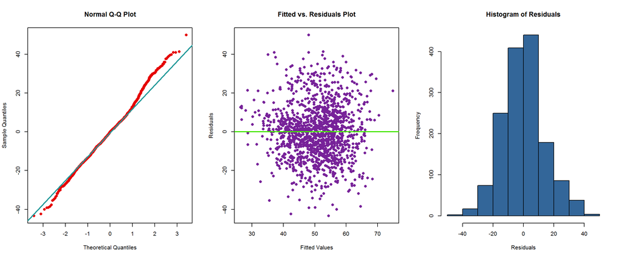

```r
anova(surgeon_selective_model, surgeon_full_additive_model)
```

```
## Analysis of Variance Table
##
## Model 1: KneeScore_Surgeon ~ Age + Year + Diagnosis + Side + KneeScore_Patient +
##     TibialInsertModel
## Model 2: KneeScore_Surgeon ~ Surgeon + Year + Age + Gender + Weight +
##     Height + BMI + Diagnosis + Race + Side + KneeScore_Patient +
##     GPS + Manufacturer + FemoralComponentModel + FemoralComponentSize +
##     FemoralComponentType + TibialTrayModel + TibialTraySize +
##     TibialInsertModel + TibialInsertWidth + TibialInsertType +
##     PatellaModel + PatellaDiameter
##   Res.Df    RSS Df Sum of Sq      F Pr(>F)
## 1   1470 287580
## 2   1405 274610 65     12970 1.0209 0.4325
```

We will attempt to utilize AIC and BIC approaches and evaluate the results.

```r
surgeon_model_back_aic = step(surgeon_full_additive_model, direction = "backward", trace = 0)
evaluate(surgeon_model_back_aic)
```

```
##                   Test       Result
## 1  Shapiro Wilk pvalue 2.104627e-05
## 2 Breusch-Pagan pvalue 0.0005527278
## 3            R Squared    0.2242163
## 4        Adj R Squared     0.214257
## 5     Cross Validation     14.08948
## 6     Large Hat Values           84
## 7          Influential           69
```

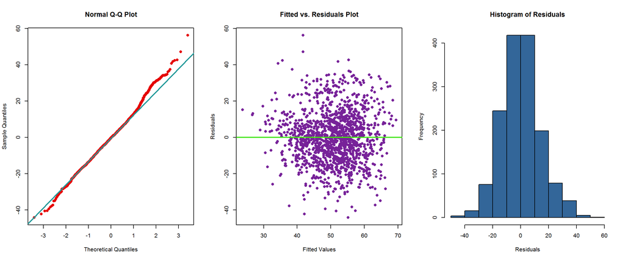

```r
anova(surgeon_model_back_aic, surgeon_full_additive_model)
```

```
## Analysis of Variance Table
##
## Model 1: KneeScore_Surgeon ~ Surgeon + Year + Age + BMI + Diagnosis +
##     Side + KneeScore_Patient
## Model 2: KneeScore_Surgeon ~ Surgeon + Year + Age + Gender + Weight +
##     Height + BMI + Diagnosis + Race + Side + KneeScore_Patient +
##     GPS + Manufacturer + FemoralComponentModel + FemoralComponentSize +
##     FemoralComponentType + TibialTrayModel + TibialTraySize +
##     TibialInsertModel + TibialInsertWidth + TibialInsertType +
##     PatellaModel + PatellaDiameter
##   Res.Df    RSS Df Sum of Sq      F Pr(>F)
## 1   1480 289849
## 2   1405 274610 75     15239 1.0396 0.3886
```

Removing the Influential observations and running AIC again.

```r
clean_dataset_aic = removeInfluential(surgeon_model_back_aic, train_data)
surgeon_full_additive_model_clean = lm(KneeScore_Surgeon ~ ., data = clean_dataset_aic)
surgeon_model_aic_clean = step(surgeon_full_additive_model_clean, direction = "backward", trace = 0)
evaluate(surgeon_model_aic_clean)
```

```
##                   Test       Result
## 1  Shapiro Wilk pvalue 0.0005509076
## 2 Breusch-Pagan pvalue 4.222397e-05
## 3            R Squared    0.2626678
## 4        Adj R Squared    0.2522092
## 5     Cross Validation     12.56518
## 6     Large Hat Values           61
## 7          Influential           36
```

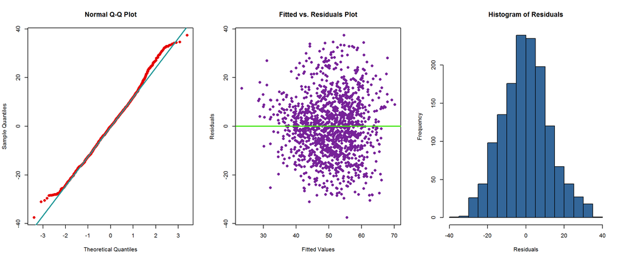

```r
anova(surgeon_model_aic_clean, surgeon_full_additive_model_clean)
```

```
## Analysis of Variance Table
##
## Model 1: KneeScore_Surgeon ~ Surgeon + Year + Age + Gender + BMI + Diagnosis +
##     Side + KneeScore_Patient
## Model 2: KneeScore_Surgeon ~ Surgeon + Year + Age + Gender + Weight +
##     Height + BMI + Diagnosis + Race + Side + KneeScore_Patient +
##     GPS + Manufacturer + FemoralComponentModel + FemoralComponentSize +
##     FemoralComponentType + TibialTrayModel + TibialTraySize +
##     TibialInsertModel + TibialInsertWidth + TibialInsertType +
##     PatellaModel + PatellaDiameter
##   Res.Df    RSS Df Sum of Sq     F Pr(>F)
## 1   1410 220498
## 2   1336 209068 74     11429 0.987 0.5107
```

Utilize a Bayesian Information Criterion approach and evaluate the selected model.

```r
n = length(resid(surgeon_full_additive_model))
surgeon_model_back_bic = step(surgeon_full_additive_model, direction = "backward", k = log(n), trace = 0)
evaluate(surgeon_model_back_bic)
```

```
##                   Test       Result
## 1  Shapiro Wilk pvalue 0.0002384827
## 2 Breusch-Pagan pvalue  0.004016612
## 3            R Squared    0.1956354
## 4        Adj R Squared    0.1934833
## 5     Cross Validation      14.2052
## 6     Large Hat Values           70
## 7          Influential           93
```

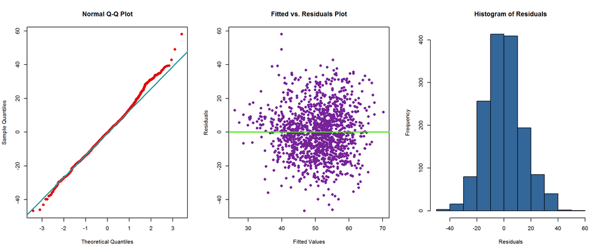

```r
anova(surgeon_model_back_bic, surgeon_full_additive_model)
```

```
## Analysis of Variance Table
##
## Model 1: KneeScore_Surgeon ~ Age + Side + KneeScore_Patient
## Model 2: KneeScore_Surgeon ~ Surgeon + Year + Age + Gender + Weight +
##     Height + BMI + Diagnosis + Race + Side + KneeScore_Patient +
##     GPS + Manufacturer + FemoralComponentModel + FemoralComponentSize +
##     FemoralComponentType + TibialTrayModel + TibialTraySize +
##     TibialInsertModel + TibialInsertWidth + TibialInsertType +
##     PatellaModel + PatellaDiameter
##   Res.Df    RSS Df Sum of Sq      F   Pr(>F)
## 1   1495 300527
## 2   1405 274610 90     25917 1.4734 0.003338 **
## ---
## Signif. codes:  0 '***' 0.001 '**' 0.01 '*' 0.05 '.' 0.1 ' ' 1
```

The resulting BIC model scores marginally better in cross validation though the anova results clearly prefer the full additive model.

Lets try the interaction between the predictors which we got in the model selected by Backward BIC.

```r
surgeon_model_back_bic_int = lm(KneeScore_Surgeon ~ Age * Side * KneeScore_Patient, data = train_data)
evaluate(surgeon_model_back_bic_int)
```

```
##                   Test       Result
## 1  Shapiro Wilk pvalue  5.07022e-05
## 2 Breusch-Pagan pvalue 0.0003413139
## 3            R Squared    0.2200762
## 4        Adj R Squared    0.2143106
## 5     Cross Validation     14.08071
## 6     Large Hat Values          142
## 7          Influential           91
```

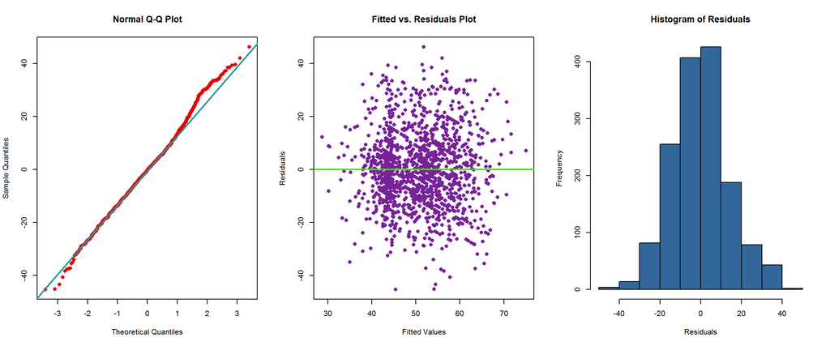

```r
anova(surgeon_model_back_bic_int, surgeon_full_additive_model)
```

```
## Analysis of Variance Table
##
## Model 1: KneeScore_Surgeon ~ Age * Side * KneeScore_Patient
## Model 2: KneeScore_Surgeon ~ Surgeon + Year + Age + Gender + Weight +
##     Height + BMI + Diagnosis + Race + Side + KneeScore_Patient +
##     GPS + Manufacturer + FemoralComponentModel + FemoralComponentSize +
##     FemoralComponentType + TibialTrayModel + TibialTraySize +
##     TibialInsertModel + TibialInsertWidth + TibialInsertType +
##     PatellaModel + PatellaDiameter
##   Res.Df    RSS Df Sum of Sq      F Pr(>F)
## 1   1488 291396
## 2   1405 274610 83     16786 1.0347 0.3967
```

Perhaps removing some influential data points will assist in creating a better model. Next we remove influential points that satisfy the criteria for `Large Cook's Distance` values and evaluating BIC again.

```r
clean_dataset = removeInfluential(surgeon_model_back_bic, train_data)
surgeon_full_additive_model_clean = lm(KneeScore_Surgeon ~ ., data = clean_dataset)
surgeon_model_back_bic_clean = step(surgeon_full_additive_model_clean, direction = "backward", k = log(n), trace = 0)

evaluate(surgeon_model_back_bic_clean)
```

```
##                   Test       Result
## 1  Shapiro Wilk pvalue   0.01095667
## 2 Breusch-Pagan pvalue 4.095323e-06
## 3            R Squared    0.2469556
## 4        Adj R Squared    0.2448071
## 5     Cross Validation     12.19531
## 6     Large Hat Values           74
## 7          Influential           50
```

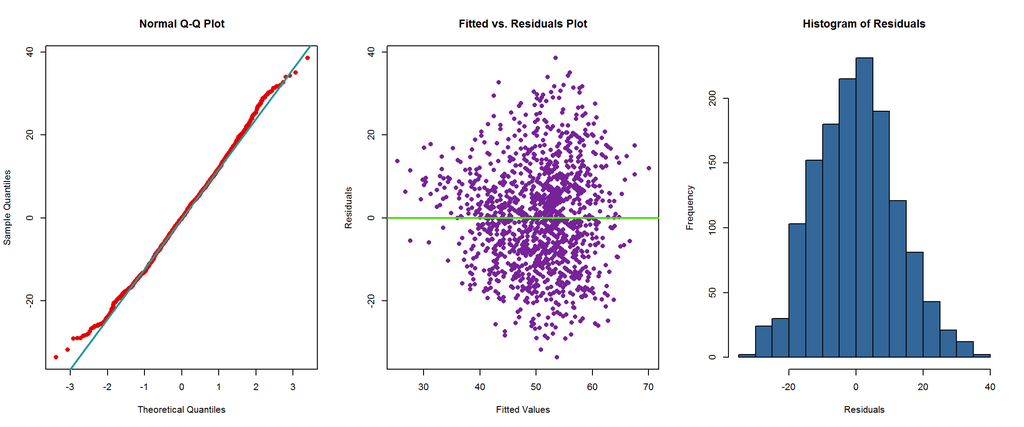

```r
anova(surgeon_model_back_bic_clean, surgeon_full_additive_model_clean)
```

```
## Analysis of Variance Table
##
## Model 1: KneeScore_Surgeon ~ Age + Side + KneeScore_Patient
## Model 2: KneeScore_Surgeon ~ Surgeon + Year + Age + Gender + Weight +
##     Height + BMI + Diagnosis + Race + Side + KneeScore_Patient +
##     GPS + Manufacturer + FemoralComponentModel + FemoralComponentSize +
##     FemoralComponentType + TibialTrayModel + TibialTraySize +
##     TibialInsertModel + TibialInsertWidth + TibialInsertType +
##     PatellaModel + PatellaDiameter
##   Res.Df    RSS Df Sum of Sq      F  Pr(>F)
## 1   1402 207871
## 2   1312 189801 90     18070 1.3879 0.01146 *
## ---
## Signif. codes:  0 '***' 0.001 '**' 0.01 '*' 0.05 '.' 0.1 ' ' 1
```

How about interaction on clean dataset-

```r
surgeon_model_back_bic_int_clean = lm(KneeScore_Surgeon ~ Age * Side * KneeScore_Patient, data = clean_dataset)
evaluate(surgeon_model_back_bic_int_clean)
```

```
##                   Test       Result
## 1  Shapiro Wilk pvalue  0.008459296
## 2 Breusch-Pagan pvalue 6.355814e-05
## 3            R Squared    0.2599312
## 4        Adj R Squared    0.2540956
## 5     Cross Validation     12.13463
## 6     Large Hat Values          143
## 7          Influential           40
```

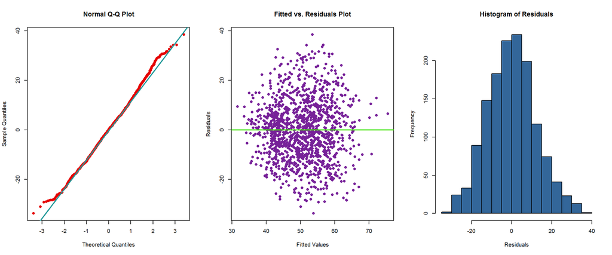

comparing BIC and Interaction Models

```r
anova(surgeon_model_back_bic_clean, surgeon_model_back_bic_int_clean)
```

```
## Analysis of Variance Table
##
## Model 1: KneeScore_Surgeon ~ Age + Side + KneeScore_Patient
## Model 2: KneeScore_Surgeon ~ Age * Side * KneeScore_Patient
##   Res.Df    RSS Df Sum of Sq      F   Pr(>F)
## 1   1402 207871
## 2   1395 204289  7    3581.8 3.4941 0.001013 **
## ---
## Signif. codes:  0 '***' 0.001 '**' 0.01 '*' 0.05 '.' 0.1 ' ' 1
```

Based on Anova test we can reject the `surgeon_model_back_bic_clean` model and prefer surgeon_model_back_bic_int_clean.

Next, we will evaluate the RMSE of the best performing models thus far.

| Model | Train RMSE | Test RMSE |
| --- | --- | --- |
| `Model All+` | 13.5304545 | 15.0174947 |
| `Selective Model` | 13.8462897 | 14.7887311 |
| `Model AIC` | 13.9008092 | 14.8544579 |
| `Model BIC` | 14.1545555 | 14.9362857 |
| `Model Int` | 13.9378522 | 14.8323282 |
| `Model Clean All+` | 13.7186255 | 15.0245954 |
| `Model Clean AIC` | 13.9282386 | 14.911542 |
| `Model Clean BIC` | 14.1619873 | 14.9304932 |
| `Model Clean Int` | 14.0027414 | 14.8527176 |

### Knee Score Patient

Begin by fitting a full additive model as a baseline and evaluating.

```r
pat_full_additive_model = lm(KneeScore_Patient ~ ., data = train_data)
evaluate(pat_full_additive_model)
```

```
##                   Test       Result
## 1  Shapiro Wilk pvalue 2.207823e-10
## 2 Breusch-Pagan pvalue    0.2417167
## 3            R Squared    0.3128778
## 4        Adj R Squared    0.2669066
## 5     Cross Validation     16.90111
## 6     Large Hat Values          166
## 7          Influential           NA
```

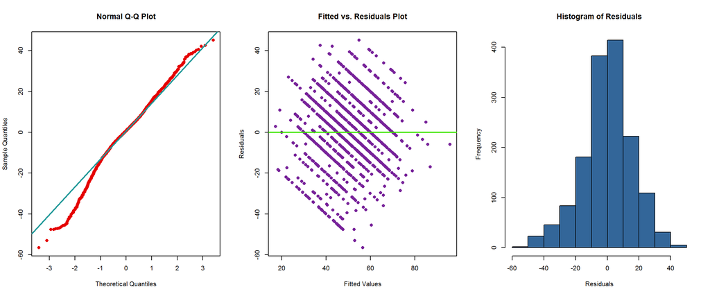

The baseline model has many large leverage values, which, upon inspection may be coming from several of the implant fields. Perhaps removing the suspect implant predictors will help improve the model.

```r
largeHat_pat = which(hatvalues(pat_full_additive_model) > (2 * mean(hatvalues(pat_full_additive_model))))
print(knee[75, ])
```

```
##    Surgeon Year Age Gender Weight Height   BMI      Diagnosis  Race
## 75       1 2010  70 Female    152     65 25.32 Osteoarthritis White
##         Side KneeScore_Surgeon KneeScore_Patient GPS   Manufacturer
## 75 Bilateral                23                80  No Smith & Nephew
##    FemoralComponentModel FemoralComponentSize FemoralComponentType
## 75                Legion                    5   cruciate retaining
##    TibialTrayModel TibialTraySize TibialInsertModel TibialInsertWidth
## 75      Genesis II              4        Genesis II                 9
##    TibialInsertType PatellaModel PatellaDiameter
## 75        high flex   Genesis II              35
```

Next we will try to determine which predictors are significant by comparing the full model to models each with a single predictor removed. Evaluation of this code is set to false for convienience. Comments show the significance of each test.

```r
patient_full_additive_model = lm(KneeScore_Patient ~ ., data = knee)
summary(patient_full_additive_model)
patient_additive_model = lm(KneeScore_Patient ~ .-Surgeon, data = knee)
Gender_additive_model = lm(KneeScore_Patient ~ .-Gender, data = knee)
Race_additive_model = lm(KneeScore_Patient ~ .- Race, data = knee)
Year_additive_model = lm(KneeScore_Patient ~ .- Year, data = knee)
Age_additive_model = lm(KneeScore_Patient ~ .- Age, data = knee)
Weight_additive_model = lm(KneeScore_Patient ~ .- Weight, data = knee)
Height_additive_model = lm(KneeScore_Patient ~ .- Height, data = knee)
BMI_additive_model = lm(KneeScore_Patient ~ .- BMI, data = knee)
Diagnosis_additive_model = lm(KneeScore_Patient ~ .- Diagnosis, data = knee)
Side_additive_model = lm(KneeScore_Patient ~ .- Side, data = knee)
KneeScore_Surgeon_additive_model = lm(KneeScore_Patient ~ .- KneeScore_Surgeon, data = knee)
GPS_additive_model = lm(KneeScore_Patient ~ .- GPS, data = knee)
Manufacturer_additive_model = lm(KneeScore_Patient ~ .- Manufacturer, data = knee)
FemoralComponentModel_additive_model = lm(KneeScore_Patient ~ .- FemoralComponentModel, data = knee)
FemoralComponentSize_additive_model = lm(KneeScore_Patient ~ .- FemoralComponentSize, data = knee)
FemoralComponentType_additive_model = lm(KneeScore_Patient ~ .- FemoralComponentType, data = knee)
TibialTrayModel_additive_model = lm(KneeScore_Patient ~ .- TibialTrayModel, data = knee)
TibialTraySize_additive_model = lm(KneeScore_Patient ~ .- TibialTraySize, data = knee)
TibialInsertModel_additive_model = lm(KneeScore_Patient ~ .- TibialInsertModel, data = knee)
TibialInsertWidth_additive_model = lm(KneeScore_Patient ~ .- TibialInsertWidth, data = knee)
TibialInsertType_additive_model = lm(KneeScore_Patient ~ .- TibialInsertType, data = knee)
PatellaModel_additive_model = lm(KneeScore_Patient ~ .- PatellaModel, data = knee)
PatellaDiameter_additive_model = lm(KneeScore_Patient ~ .- PatellaDiameter, data = knee)
summary(surgeon_full_additive_model)
anova(surgeon_additive_model,patient_full_additive_model)
anova(Gender_additive_model,patient_full_additive_model) ##Not significant
anova(Race_additive_model,patient_full_additive_model) ##Not significant
anova(Year_additive_model,patient_full_additive_model)  ## sort of
anova(Age_additive_model,patient_full_additive_model) ## Not significant
anova(Weight_additive_model,patient_full_additive_model)
anova(Height_additive_model,patient_full_additive_model)
anova(BMI_additive_model,patient_full_additive_model)
anova(Diagnosis_additive_model,patient_full_additive_model)
anova(Side_additive_model,patient_full_additive_model)
anova(KneeScore_Patient_additive_model,patient_full_additive_model) ## Not significant
anova(GPS_additive_model,patient_full_additive_model)
anova(Manufacturer_additive_model,patient_full_additive_model)
anova(FemoralComponentModel_additive_model,patient_full_additive_model)
anova(FemoralComponentSize_additive_model,patient_full_additive_model)
anova(FemoralComponentType_additive_model,patient_full_additive_model)
anova(TibialTrayModel_additive_model,patient_full_additive_model)
anova(TibialTraySize_additive_model,patient_full_additive_model)

anova(TibialInsertModel_additive_model,patient_full_additive_model)
anova(TibialTraySize_additive_model,patient_full_additive_model)
anova(TibialInsertModel_additive_model,patient_full_additive_model)
anova(TibialInsertWidth_additive_model,patient_full_additive_model)

anova(TibialInsertType_additive_model,patient_full_additive_model)
anova(PatellaModel_additive_model,patient_full_additive_model) ##sort ofa
anova(PatellaDiameter_additive_model,patient_full_additive_model)
```

```r
pat_selective_model = lm(KneeScore_Patient ~ . - Diagnosis - Race - TibialInsertType - FemoralComponentModel - PatellaModel - TibialTrayModel - TibialTraySize - FemoralComponentType, data = train_data)
evaluate(pat_selective_model)
```

```
##                   Test       Result
## 1  Shapiro Wilk pvalue 8.533813e-11
## 2 Breusch-Pagan pvalue 0.0003120659
## 3            R Squared    0.2909512
## 4        Adj R Squared    0.2639445
## 5     Cross Validation      16.7017
## 6     Large Hat Values           97
## 7          Influential           NA
```

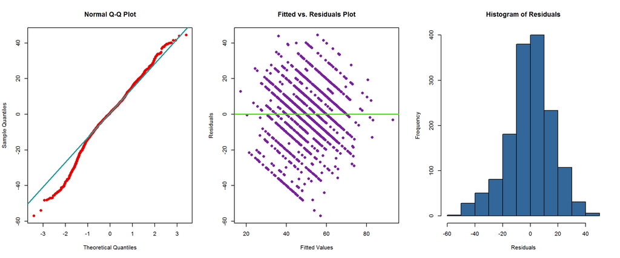

```r
anova(pat_selective_model, pat_full_additive_model)
```

```
## Analysis of Variance Table
##
## Model 1: KneeScore_Patient ~ (Surgeon + Year + Age + Gender + Weight +
##     Height + BMI + Diagnosis + Race + Side + KneeScore_Surgeon +
##     GPS + Manufacturer + FemoralComponentModel + FemoralComponentSize +
##     FemoralComponentType + TibialTrayModel + TibialTraySize +
##     TibialInsertModel + TibialInsertWidth + TibialInsertType +
##     PatellaModel + PatellaDiameter) - Diagnosis - Race - TibialInsertType -
##     FemoralComponentModel - PatellaModel - TibialTrayModel -
##     TibialTraySize - FemoralComponentType
## Model 2: KneeScore_Patient ~ Surgeon + Year + Age + Gender + Weight +
##     Height + BMI + Diagnosis + Race + Side + KneeScore_Surgeon +
##     GPS + Manufacturer + FemoralComponentModel + FemoralComponentSize +
##     FemoralComponentType + TibialTrayModel + TibialTraySize +
##     TibialInsertModel + TibialInsertWidth + TibialInsertType +
##     PatellaModel + PatellaDiameter
##   Res.Df    RSS Df Sum of Sq      F Pr(>F)
## 1   1444 389632
## 2   1405 377583 39     12049 1.1496 0.2444
```

Backward AIC

```r
pat_aic = step(pat_full_additive_model, direction = "backward", trace = 0)
evaluate(pat_aic)
```

```
##                   Test       Result
## 1  Shapiro Wilk pvalue 2.356167e-11
## 2 Breusch-Pagan pvalue 6.583011e-06
## 3            R Squared    0.2730788
## 4        Adj R Squared    0.2627505
## 5     Cross Validation     16.69035
## 6     Large Hat Values          162
## 7          Influential           77
```

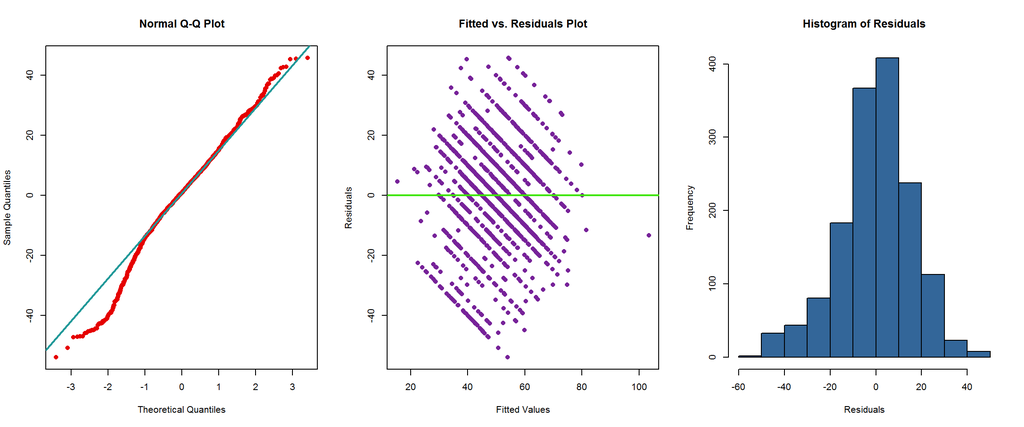

```r
anova(pat_aic, pat_full_additive_model)
```

```
## Analysis of Variance Table
##
## Model 1: KneeScore_Patient ~ Surgeon + Age + Gender + Weight + Height +
##     Diagnosis + Race + KneeScore_Surgeon + TibialTraySize + PatellaDiameter
## Model 2: KneeScore_Patient ~ Surgeon + Year + Age + Gender + Weight +
##     Height + BMI + Diagnosis + Race + Side + KneeScore_Surgeon +
##     GPS + Manufacturer + FemoralComponentModel + FemoralComponentSize +
##     FemoralComponentType + TibialTrayModel + TibialTraySize +
##     TibialInsertModel + TibialInsertWidth + TibialInsertType +
##     PatellaModel + PatellaDiameter
##   Res.Df    RSS Df Sum of Sq      F Pr(>F)
## 1   1478 399453
## 2   1405 377583 73     21870 1.1148 0.2416
```

Backward AIC - Cleaned

```r
clean_data_aic = removeInfluential(pat_aic, train_data)
pat_full_additive_model_clean = lm(KneeScore_Patient ~ ., data = clean_data_aic)
pat_aic_clean = step(pat_full_additive_model_clean, direction = "backward", trace = 0)
evaluate(pat_aic_clean)
```

```
##                   Test       Result
## 1  Shapiro Wilk pvalue 8.611184e-09
## 2 Breusch-Pagan pvalue 0.0003964887
## 3            R Squared     0.266989
## 4        Adj R Squared     0.263883
## 5     Cross Validation     15.28082
## 6     Large Hat Values           68
## 7          Influential           93
```

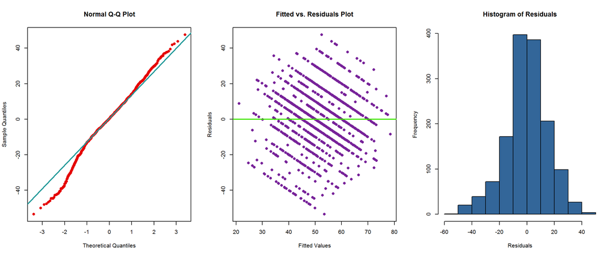

```r
anova(pat_aic_clean, pat_full_additive_model_clean)
```

```
## Analysis of Variance Table
##
## Model 1: KneeScore_Patient ~ Age + Gender + Weight + Height + KneeScore_Surgeon +
##     PatellaDiameter
## Model 2: KneeScore_Patient ~ Surgeon + Year + Age + Gender + Weight +
##     Height + BMI + Diagnosis + Race + Side + KneeScore_Surgeon +
##     GPS + Manufacturer + FemoralComponentModel + FemoralComponentSize +
##     FemoralComponentType + TibialTrayModel + TibialTraySize +
##     TibialInsertModel + TibialInsertWidth + TibialInsertType +
##     PatellaModel + PatellaDiameter
##   Res.Df    RSS Df Sum of Sq      F Pr(>F)
## 1   1416 329093
## 2   1329 308179 87     20914 1.0367 0.3909
```

Backward BIC

```r
n = length(resid(pat_full_additive_model))
pat_bic = step(pat_full_additive_model, direction = "backward", k = log(n), trace = 0)
evaluate(pat_bic)
```

```
##                   Test       Result
## 1  Shapiro Wilk pvalue 2.052476e-12
## 2 Breusch-Pagan pvalue 2.450005e-07
## 3            R Squared    0.2513452
## 4        Adj R Squared    0.2488397
## 5     Cross Validation      16.6308
## 6     Large Hat Values           91
## 7          Influential          112
```

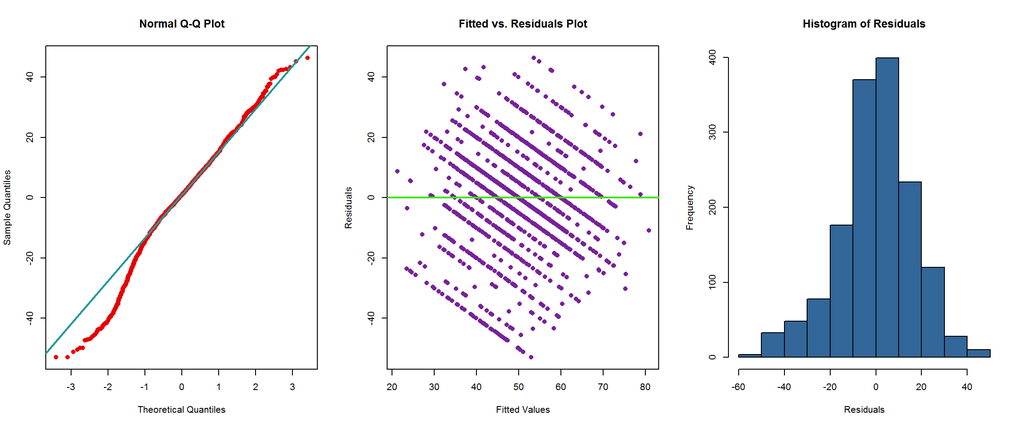

```r
anova(pat_bic, pat_full_additive_model)
```

```
## Analysis of Variance Table
##
## Model 1: KneeScore_Patient ~ Age + Gender + Weight + Height + KneeScore_Surgeon
## Model 2: KneeScore_Patient ~ Surgeon + Year + Age + Gender + Weight +
##     Height + BMI + Diagnosis + Race + Side + KneeScore_Surgeon +
##     GPS + Manufacturer + FemoralComponentModel + FemoralComponentSize +
##     FemoralComponentType + TibialTrayModel + TibialTraySize +
##     TibialInsertModel + TibialInsertWidth + TibialInsertType +
##     PatellaModel + PatellaDiameter
##   Res.Df    RSS Df Sum of Sq      F   Pr(>F)
## 1   1494 411396
## 2   1405 377583 89     33813 1.4137 0.008166 **
## ---
## Signif. codes:  0 '***' 0.001 '**' 0.01 '*' 0.05 '.' 0.1 ' ' 1
```

Backward BIC - Cleaned

```r
clean_data_bic = removeInfluential(pat_bic, train_data)
pat_full_additive_model_clean_bic = lm(KneeScore_Patient ~ ., data = clean_data_bic)
n = length(resid(pat_full_additive_model_clean_bic))
pat_bic_clean = step(pat_full_additive_model_clean_bic, direction = "backward", k = log(n), trace = 0)
evaluate(pat_bic_clean)
```

```
##                   Test      Result
## 1  Shapiro Wilk pvalue 7.55758e-05
## 2 Breusch-Pagan pvalue 0.001917982
## 3            R Squared   0.2739038
## 4        Adj R Squared   0.2712769
## 5     Cross Validation    13.52945
## 6     Large Hat Values          76
## 7          Influential          57
```

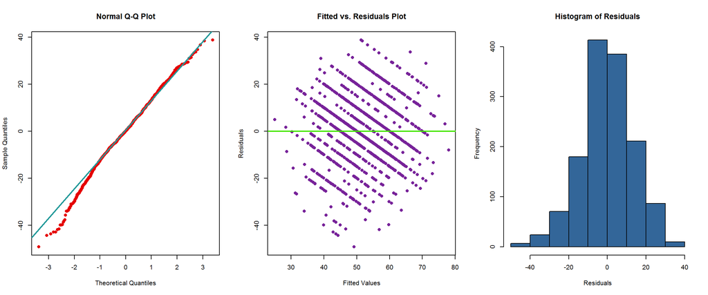

```r
anova(pat_bic_clean, pat_full_additive_model_clean_bic)
```

```
## Analysis of Variance Table
##
## Model 1: KneeScore_Patient ~ Age + Gender + Weight + Height + KneeScore_Surgeon
## Model 2: KneeScore_Patient ~ Surgeon + Year + Age + Gender + Weight +
##     Height + BMI + Diagnosis + Race + Side + KneeScore_Surgeon +
##     GPS + Manufacturer + FemoralComponentModel + FemoralComponentSize +
##     FemoralComponentType + TibialTrayModel + TibialTraySize +
##     TibialInsertModel + TibialInsertWidth + TibialInsertType +
##     PatellaModel + PatellaDiameter
##   Res.Df    RSS Df Sum of Sq      F Pr(>F)
## 1   1382 252088
## 2   1293 233965 89     18123 1.1253 0.2063
```

Interaction Models

```r
pat_bic_int = lm(KneeScore_Patient ~ Age * Weight * Height * Gender * KneeScore_Surgeon, data = train_data)
evaluate(pat_bic_int)
```

```
##                   Test       Result
## 1  Shapiro Wilk pvalue 1.114525e-10
## 2 Breusch-Pagan pvalue 1.490931e-05
## 3            R Squared    0.2716246
## 4        Adj R Squared    0.2562434
## 5     Cross Validation     16.69436
## 6     Large Hat Values          166
## 7          Influential           82
```

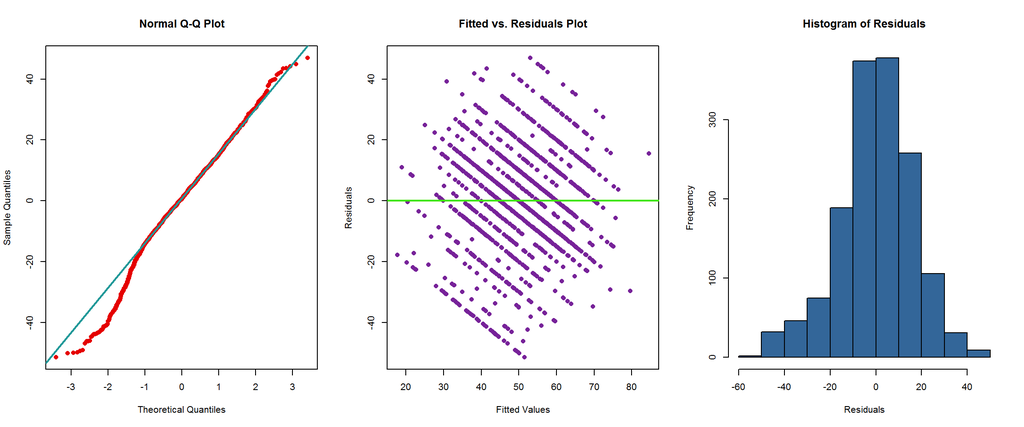

```r
anova(pat_bic_int, pat_full_additive_model )
```

```
## Analysis of Variance Table
##
## Model 1: KneeScore_Patient ~ Age * Weight * Height * Gender * KneeScore_Surgeon
## Model 2: KneeScore_Patient ~ Surgeon + Year + Age + Gender + Weight +
##     Height + BMI + Diagnosis + Race + Side + KneeScore_Surgeon +
##     GPS + Manufacturer + FemoralComponentModel + FemoralComponentSize +
##     FemoralComponentType + TibialTrayModel + TibialTraySize +
##     TibialInsertModel + TibialInsertWidth + TibialInsertType +
##     PatellaModel + PatellaDiameter
##   Res.Df    RSS Df Sum of Sq      F  Pr(>F)
## 1   1468 400252
## 2   1405 377583 63     22669 1.3389 0.04179 *
## ---
## Signif. codes:  0 '***' 0.001 '**' 0.01 '*' 0.05 '.' 0.1 ' ' 1
```

Interaction Models - Cleaned

```r
pat_bic_int_clean = lm(KneeScore_Patient ~ Age * Weight * Height * Gender * KneeScore_Surgeon, data = clean_data_bic)
evaluate(pat_bic_int_clean)
```

```
##                   Test       Result
## 1  Shapiro Wilk pvalue 3.384644e-05
## 2 Breusch-Pagan pvalue   0.04563719
## 3            R Squared    0.2837565
## 4        Adj R Squared    0.2673822
## 5     Cross Validation     13.64028
## 6     Large Hat Values          155
## 7          Influential           48
```

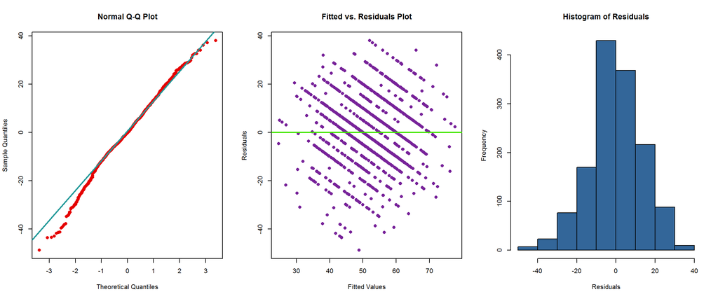

```r
anova(pat_bic_int_clean, pat_bic_clean)
```

```
## Analysis of Variance Table
##
## Model 1: KneeScore_Patient ~ Age * Weight * Height * Gender * KneeScore_Surgeon
## Model 2: KneeScore_Patient ~ Age + Gender + Weight + Height + KneeScore_Surgeon
##   Res.Df    RSS  Df Sum of Sq      F Pr(>F)
## 1   1356 248667
## 2   1382 252088 -26   -3420.7 0.7174 0.8493
```

Next, we will evaluate the RMSE of the best performing models thus far.

```r
options(warn=-1)

full_test = rmse(test_data$KneeScore_Patient, predict(pat_full_additive_model, test_data))
full_train = rmse(train_data$KneeScore_Patient, predict(pat_full_additive_model, train_data))

sel_test = rmse(test_data$KneeScore_Patient, predict(pat_selective_model, test_data))
sel_train = rmse(train_data$KneeScore_Patient, predict(pat_selective_model, train_data))

clean_full_test = rmse(test_data$KneeScore_Patient, predict(pat_full_additive_model_clean, test_data))
clean_full_train = rmse(train_data$KneeScore_Patient, predict(pat_full_additive_model_clean, train_data))

aic_test = rmse(test_data$KneeScore_Patient, predict(pat_aic, test_data))
aic_train = rmse(train_data$KneeScore_Patient, predict(pat_aic, train_data))

clean_aic_test = rmse(test_data$KneeScore_Patient, predict(pat_aic_clean, test_data))
clean_aic_train = rmse(train_data$KneeScore_Patient, predict(pat_aic_clean, train_data))

bic_test = rmse(test_data$KneeScore_Patient, predict(pat_bic, test_data))
bic_train = rmse(train_data$KneeScore_Patient, predict(pat_bic, train_data))

int_test = rmse(test_data$KneeScore_Patient, predict(pat_bic_int, test_data))
int_train = rmse(train_data$KneeScore_Patient, predict(pat_bic_int, train_data))

clean_bic_test = rmse(test_data$KneeScore_Patient, predict(pat_bic_clean, test_data))
clean_bic_train = rmse(train_data$KneeScore_Patient, predict(pat_bic_clean, train_data))

clean_int_bic_test = rmse(test_data$KneeScore_Patient, predict(pat_bic_int_clean, test_data))
clean_int_bic_train = rmse(train_data$KneeScore_Patient, predict(pat_bic_int_clean, train_data))
```

[output not shown]

## Conclusion

1. Does the satisfactory score is dependent on different age groups?
2. Score improvement of GPS vs manual placement?
3. Does score depends on the gender?
4. Does GPS improved score based on surgeons?
5. Are devices from various vendors more suitable for GPS placement or not?
6. Satisfacory scores depends on BMI, H, W?
7. Are some vendors more suitable various BMI, H, W?
8. Is there any dependencies between scores and various replacemnt components?
9. What components seems to matter the most on the score?
10. Is there any relationship between components from various vendors and race?
11. Based on race and gender which has the higher score?

## Appendix

```r
# Warning: takes hours to fit
all_two_way_model = lm(KneeScore_Surgeon ~ .*., data = knee)
```

```r
# Warning...
n = length(resid(all_two_way_model))
model_one_bic_all_two_way = step(all_two_way_model, direction = 'backward', k = log(n), trace = 0)
```

```r
model_one_pat = lm(log(KneeScore_Patient) ~ ., data = knee)
model_one_surg = lm(log(KneeScore_Surgoen) ~ ., data = knee)
```

```r
model_two_exp_pat= lm(KneeScore_Patient^2 ~ ., data = knee)
model_two_exp_surg = lm(KneeScore_Surgeon^2 ~ ., data = knee)
```

```r
# replace all 0 values with the mean of the vector
temp = knee
temp$KneeScore_Patient[temp$KneeScore_Patient == 0] = mean(temp$KneeScore_Patient)

model_three = lm(KneeScore_Patient ~ ., data = temp)
evaluate(model_five)
```

```r
clean_temp_data = removeLargeHatValues(model_three, temp)
model_four = lm(KneeScore_Patient ~ ., data = clean_temp_data)
evaluate(model_four)
```

```r
pat_model = lm(KneeScore_Patient ~. , data = knee)
pat_model_back_aic = step(pat_model, direction = "backward", trace = 0)
pat_model_for_aic = step(pat_model, direction = "forward", trace = 0)
pat_model_both_aic = step(pat_model, direction = "both", trace = 0)

n = length(resid(pat_model))
pat_model_back_bic = step(pat_model, direction = "backward", k = log(n), trace = 0)
pat_model_for_bic = step(pat_model, direction = "forward", k = log(n), trace = 0)
pat_model_both_bic = step(pat_model, direction = "both", k = log(n), trace = 0)
```

```r
evaluate(pat_model)
```

```r
evaluate(pat_model_back_aic)
```

```r
evaluate(pat_model_for_aic)
```

```r
evaluate(pat_model_both_aic)
```

```r
## Adj.R.Squared: 0.24 - CrossValidation: 16.9
evaluate(pat_model_back_bic)
```

```r
evaluate(pat_model_for_bic)
```

```r
evaluate(pat_model_both_bic)
```

```r
## Remove large leverages
new_data = removeInfluential(pat_model, knee)
pat_model_without_large_leverages = lm(KneeScore_Patient ~ ., data = new_data)
evaluate(pat_model_without_large_leverages)
```

Removing the records with large hat values and refitting simply introduces more large hat values. What is unique about these rows of data?

```r
which(hatvalues(pat_model) == 1.0)
print(knee[17,])
print(knee[240,])
print(knee[638,])
print(knee[1093,])
print(knee[1775, ])
```

```r
pat_model_nine = lm(KneeScore_Patient ~ . - TibialInsertType - FemoralComponentModel - PatellaModel - TibialTrayModel - FemoralComponentType, data = knee)
evaluate(pat_model_nine)
```